# Long Run Outcomes in Perfect Competition

October 29, 2018

## Pregame

- Writing Assignment 3 is on Blackboard and is due to NetTutor on Wednesday Nov 7th by 5pm.
- Practice test will be available tonight
- We’ll go over both before class

## Feedback

### Good:

Are there things in place to prevent monopolies? For example the epiPen market.

### Needs improvement:

- <no feedback…>

## Perfect competition is rare

[video not shown]

## Perfect competition in the Long Run

- **Long Run** - After firms have entered the market to drive profits down.
- **Short Run** - Hold the number of firms fixed.

**Review of Acronyms:**

- **ATC** - Average Total Cost \(\frac{TC}{Q}\)
- **AVC** - Average Variable Cost \(\frac{VC}{Q}\)
- **MC** - Marginal Cost (cost of one additional unit)
- **MR** - Marginal Revenue (revenue from one additional unit)

## Short run profit (P > ATC)

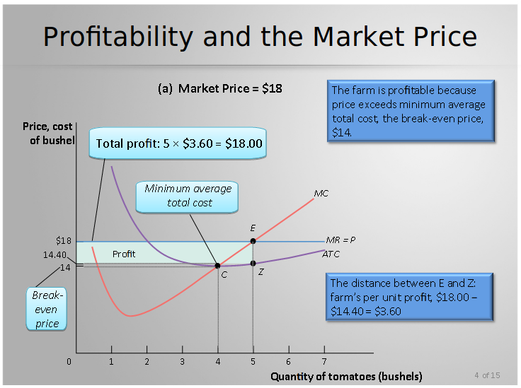

Source: Krugman and Wells.

## Short run loss (P < ATC)

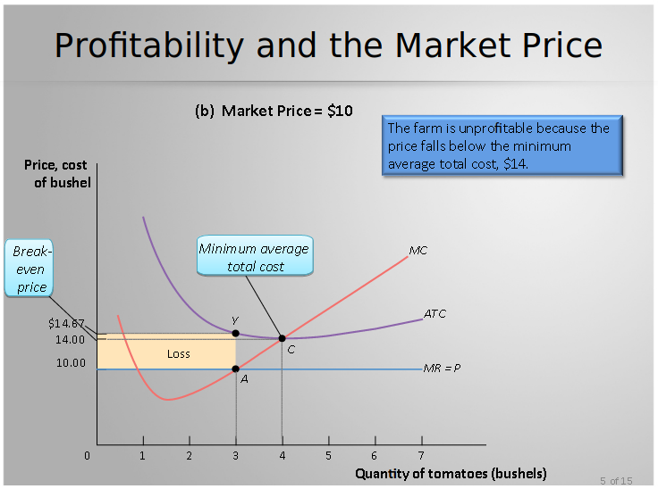

Source: Krugman and Wells.

## Short Run Supply

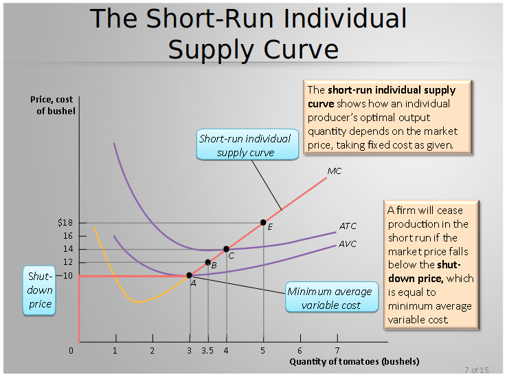

Source: Krugman and Wells.

## Short Run Equilibrium

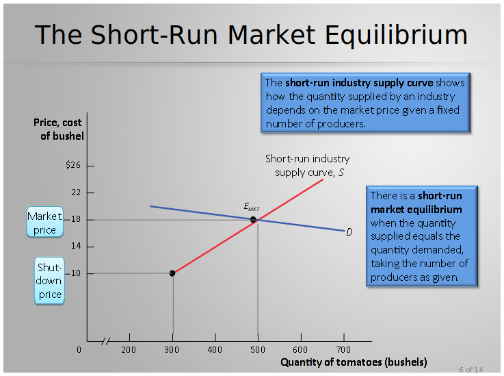

Source: Krugman and Wells.

## Long Run Equilibrium

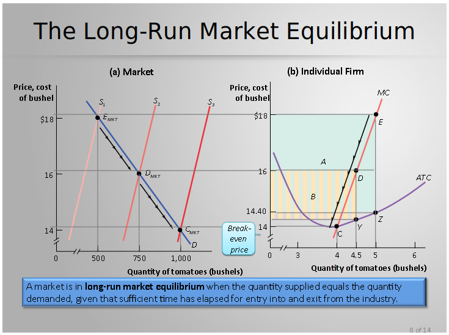

Source: Krugman and Wells.

## Time for an example…

[Google Spreadsheet](https://docs.google.com/spreadsheets/d/1EdXAIMsQ2JlJ1X7ZbzNfkbXU5yKHWLrvEZDBKlcMhtA/edit?usp=sharing)

[figure not shown]

Source: https://me.me/i/farmers-investors-nasda-nq-meme-economy-meme-insider-memes-good-13828294.

## Wrapping Up

- Complete the [knowledge check](https://goo.gl/forms/I7VSfzJRDpmpIO7w2) for today’s participation point.
- Please provide [feedback](https://goo.gl/forms/8SiOwdi19kN8cINJ3) on today’s lecture.